# World Happiness Data Analysis

Importing Required Libraries and Loading dataset

```python
import pandas as pd
import matplotlib.pyplot as plt
df_2015=pd.read_csv("Happiness_Data_2015.csv")
df_2015
```

|  | Country | Region | Happiness_Rank | Happiness_Score | GDP_Per_Capita | Healthy_Life_Expectancy | Freedom_To_Make_Life_Choices | Trust_On_Government | Generosity | Family | Dystopia_Residual | Standard_Error |
| --- | --- | --- | --- | --- | --- | --- | --- | --- | --- | --- | --- | --- |
| 0 | Switzerland | Western Europe | 1 | 7.587 | 1.39651 | 0.94143 | 0.66557 | 0.41978 | 0.29678 | 1.34951 | 2.51738 | 0.03411 |
| 1 | Iceland | Western Europe | 2 | 7.561 | 1.30232 | 0.94784 | 0.62877 | 0.14145 | 0.43630 | 1.40223 | 2.70201 | 0.04884 |
| 2 | Denmark | Western Europe | 3 | 7.527 | 1.32548 | 0.87464 | 0.64938 | 0.48357 | 0.34139 | 1.36058 | 2.49204 | 0.03328 |
| 3 | Norway | Western Europe | 4 | 7.522 | 1.45900 | 0.88521 | 0.66973 | 0.36503 | 0.34699 | 1.33095 | 2.46531 | 0.03880 |
| 4 | Canada | North America | 5 | 7.427 | 1.32629 | 0.90563 | 0.63297 | 0.32957 | 0.45811 | 1.32261 | 2.45176 | 0.03553 |
| ... | ... | ... | ... | ... | ... | ... | ... | ... | ... | ... | ... | ... |
| 153 | Rwanda | Sub-Saharan Africa | 154 | 3.465 | 0.22208 | 0.42864 | 0.59201 | 0.55191 | 0.22628 | 0.77370 | 0.67042 | 0.03464 |
| 154 | Benin | Sub-Saharan Africa | 155 | 3.340 | 0.28665 | 0.31910 | 0.48450 | 0.08010 | 0.18260 | 0.35386 | 1.63328 | 0.03656 |
| 155 | Syria | Middle East and Northern Africa | 156 | 3.006 | 0.66320 | 0.72193 | 0.15684 | 0.18906 | 0.47179 | 0.47489 | 0.32858 | 0.05015 |
| 156 | Burundi | Sub-Saharan Africa | 157 | 2.905 | 0.01530 | 0.22396 | 0.11850 | 0.10062 | 0.19727 | 0.41587 | 1.83302 | 0.08658 |
| 157 | Togo | Sub-Saharan Africa | 158 | 2.839 | 0.20868 | 0.28443 | 0.36453 | 0.10731 | 0.16681 | 0.13995 | 1.56726 | 0.06727 |

158 rows × 12 columns

```python
df_2016=pd.read_csv("Happiness_Data_2016.csv")
df_2016
```

|  | Country | Region | Happiness_Rank | Happiness_Score | GDP_Per_Capita | GDP_Per_Capita.1 | Freedom_To_Make_Life_Choices | Trust_On_Government | Generosity | Family | Dystopia_Residual | Lower_Confidence_Interval | Upper_Confidence_Interval |
| --- | --- | --- | --- | --- | --- | --- | --- | --- | --- | --- | --- | --- | --- |
| 0 | Denmark | Western Europe | 1 | 7.526 | 1.44178 | 0.79504 | 0.57941 | 0.44453 | 0.36171 | 1.16374 | 2.73939 | 7.460 | 7.592 |
| 1 | Switzerland | Western Europe | 2 | 7.509 | 1.52733 | 0.86303 | 0.58557 | 0.41203 | 0.28083 | 1.14524 | 2.69463 | 7.428 | 7.590 |
| 2 | Iceland | Western Europe | 3 | 7.501 | 1.42666 | 0.86733 | 0.56624 | 0.14975 | 0.47678 | 1.18326 | 2.83137 | 7.333 | 7.669 |
| 3 | Norway | Western Europe | 4 | 7.498 | 1.57744 | 0.79579 | 0.59609 | 0.35776 | 0.37895 | 1.12690 | 2.66465 | 7.421 | 7.575 |
| 4 | Finland | Western Europe | 5 | 7.413 | 1.40598 | 0.81091 | 0.57104 | 0.41004 | 0.25492 | 1.13464 | 2.82596 | 7.351 | 7.475 |
| ... | ... | ... | ... | ... | ... | ... | ... | ... | ... | ... | ... | ... | ... |
| 152 | Benin | Sub-Saharan Africa | 153 | 3.484 | 0.39499 | 0.21028 | 0.39747 | 0.06681 | 0.20180 | 0.10419 | 2.10812 | 3.404 | 3.564 |
| 153 | Afghanistan | Southern Asia | 154 | 3.360 | 0.38227 | 0.17344 | 0.16430 | 0.07112 | 0.31268 | 0.11037 | 2.14558 | 3.288 | 3.432 |
| 154 | Togo | Sub-Saharan Africa | 155 | 3.303 | 0.28123 | 0.24811 | 0.34678 | 0.11587 | 0.17517 | 0.00000 | 2.13540 | 3.192 | 3.414 |
| 155 | Syria | Middle East and Northern Africa | 156 | 3.069 | 0.74719 | 0.62994 | 0.06912 | 0.17233 | 0.48397 | 0.14866 | 0.81789 | 2.936 | 3.202 |
| 156 | Burundi | Sub-Saharan Africa | 157 | 2.905 | 0.06831 | 0.15747 | 0.04320 | 0.09419 | 0.20290 | 0.23442 | 2.10404 | 2.732 | 3.078 |

157 rows × 13 columns

```python
df_2017=pd.read_csv("Happiness_Data_2017.csv")
df_2017
```

|  | Country | Region | Happiness_Rank | Happiness_Score | GDP_Per_Capita | Healthy_Life_Expectancy | Freedom_To_Make_Life_Choices | Trust_On_Government | Generosity | Family | Dystopia_Residual | Whisker_high | Whisker_low |
| --- | --- | --- | --- | --- | --- | --- | --- | --- | --- | --- | --- | --- | --- |
| 0 | Norway | Western Europe | 1 | 7.537 | 1.616463 | 0.796667 | 0.635423 | 0.315964 | 0.362012 | 1.533524 | 2.277027 | 7.594445 | 7.479556 |
| 1 | Denmark | Western Europe | 2 | 7.522 | 1.482383 | 0.792566 | 0.626007 | 0.400770 | 0.355280 | 1.551122 | 2.313707 | 7.581728 | 7.462272 |
| 2 | Iceland | Western Europe | 3 | 7.504 | 1.480633 | 0.833552 | 0.627163 | 0.153527 | 0.475540 | 1.610574 | 2.322715 | 7.622030 | 7.385970 |
| 3 | Switzerland | Western Europe | 4 | 7.494 | 1.564980 | 0.858131 | 0.620071 | 0.367007 | 0.290549 | 1.516912 | 2.276716 | 7.561772 | 7.426228 |
| 4 | Finland | Western Europe | 5 | 7.469 | 1.443572 | 0.809158 | 0.617951 | 0.382612 | 0.245483 | 1.540247 | 2.430182 | 7.527542 | 7.410458 |
| ... | ... | ... | ... | ... | ... | ... | ... | ... | ... | ... | ... | ... | ... |
| 150 | Rwanda | Sub-Saharan Africa | 151 | 3.471 | 0.368746 | 0.326425 | 0.581844 | 0.455220 | 0.252756 | 0.945707 | 0.540061 | 3.543030 | 3.398970 |
| 151 | Syria | Middle East and Northern Africa | 152 | 3.462 | 0.777153 | 0.500533 | 0.081539 | 0.151347 | 0.493664 | 0.396103 | 1.061574 | 3.663669 | 3.260331 |
| 152 | Tanzania | Sub-Saharan Africa | 153 | 3.349 | 0.511136 | 0.364509 | 0.390018 | 0.066035 | 0.354256 | 1.041990 | 0.621130 | 3.461430 | 3.236570 |
| 153 | Burundi | Sub-Saharan Africa | 154 | 2.905 | 0.091623 | 0.151611 | 0.059901 | 0.084148 | 0.204435 | 0.629794 | 1.683024 | 3.074690 | 2.735310 |
| 154 | Central African Republic | Sub-Saharan Africa | 155 | 2.693 | 0.000000 | 0.018773 | 0.270842 | 0.056565 | 0.280876 | 0.000000 | 2.066005 | 2.864884 | 2.521116 |

155 rows × 13 columns

```python
df_2018=pd.read_csv("Happiness_Data_2018.csv")
df_2018
```

|  | Country | Region | Happiness_Rank | Happiness_Score | GDP_Per_Capita | Healthy_Life_Expectancy | Freedom_To_Make_Life_Choices | Trust_On_Government | Generosity | Social_support |
| --- | --- | --- | --- | --- | --- | --- | --- | --- | --- | --- |
| 0 | Finland | Western Europe | 1 | 7.632 | 1.305 | 0.874 | 0.681 | 0.393 | 0.202 | 1.592 |
| 1 | Norway | Western Europe | 2 | 7.594 | 1.456 | 0.861 | 0.686 | 0.340 | 0.286 | 1.582 |
| 2 | Denmark | Western Europe | 3 | 7.555 | 1.351 | 0.868 | 0.683 | 0.408 | 0.284 | 1.590 |
| 3 | Iceland | Western Europe | 4 | 7.495 | 1.343 | 0.914 | 0.677 | 0.138 | 0.353 | 1.644 |
| 4 | Switzerland | Western Europe | 5 | 7.487 | 1.420 | 0.927 | 0.660 | 0.357 | 0.256 | 1.549 |
| ... | ... | ... | ... | ... | ... | ... | ... | ... | ... | ... |
| 151 | Yemen | Middle East and Northern Africa | 152 | 3.355 | 0.442 | 0.343 | 0.244 | 0.064 | 0.083 | 1.073 |
| 152 | Tanzania | Sub-Saharan Africa | 153 | 3.303 | 0.455 | 0.381 | 0.481 | 0.097 | 0.270 | 0.991 |
| 153 | South Sudan | Sub-Saharan Africa | 154 | 3.254 | 0.337 | 0.177 | 0.112 | 0.106 | 0.224 | 0.608 |
| 154 | Central African Republic | Sub-Saharan Africa | 155 | 3.083 | 0.024 | 0.010 | 0.305 | 0.038 | 0.218 | 0.000 |
| 155 | Burundi | Sub-Saharan Africa | 156 | 2.905 | 0.091 | 0.145 | 0.065 | 0.076 | 0.149 | 0.627 |

156 rows × 10 columns

```python
df_2019=pd.read_csv("Happiness_Data_2019.csv")
df_2019
```

|  | Country | Region | Happiness_Rank | Happiness_Score | GDP_Per_Capita | Healthy_Life_Expectancy | Freedom_To_Make_Life_Choices | Trust_On_Government | Generosity | Social_support |
| --- | --- | --- | --- | --- | --- | --- | --- | --- | --- | --- |
| 0 | Finland | Western Europe | 1 | 7.769 | 1.340 | 0.986 | 0.596 | 0.393 | 0.153 | 1.587 |
| 1 | Denmark | Western Europe | 2 | 7.600 | 1.383 | 0.996 | 0.592 | 0.410 | 0.252 | 1.573 |
| 2 | Norway | Western Europe | 3 | 7.554 | 1.488 | 1.028 | 0.603 | 0.341 | 0.271 | 1.582 |
| 3 | Iceland | Western Europe | 4 | 7.494 | 1.380 | 1.026 | 0.591 | 0.118 | 0.354 | 1.624 |
| 4 | Netherlands | Western Europe | 5 | 7.488 | 1.396 | 0.999 | 0.557 | 0.298 | 0.322 | 1.522 |
| ... | ... | ... | ... | ... | ... | ... | ... | ... | ... | ... |
| 151 | Rwanda | Sub-Saharan Africa | 152 | 3.334 | 0.359 | 0.614 | 0.555 | 0.411 | 0.217 | 0.711 |
| 152 | Tanzania | Sub-Saharan Africa | 153 | 3.231 | 0.476 | 0.499 | 0.417 | 0.147 | 0.276 | 0.885 |
| 153 | Afghanistan | Southern Asia | 154 | 3.203 | 0.350 | 0.361 | 0.000 | 0.025 | 0.158 | 0.517 |
| 154 | Central African Republic | Sub-Saharan Africa | 155 | 3.083 | 0.026 | 0.105 | 0.225 | 0.035 | 0.235 | 0.000 |
| 155 | South Sudan | Sub-Saharan Africa | 156 | 2.853 | 0.306 | 0.295 | 0.010 | 0.091 | 0.202 | 0.575 |

156 rows × 10 columns

# Exploratory Data Analysis

1. Which countries are happiest and why (data reasons)?

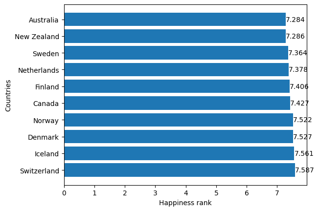

```python
top_10 = df_2015.sort_values(
    by='Happiness_Score',
    ascending=False
).head(10)

bar= plt.barh(top_10["Country"],top_10["Happiness_Score"])
plt.bar_label(bar)
plt.xlabel('Happiness rank')
plt.ylabel('Countries')
plt.show()
```

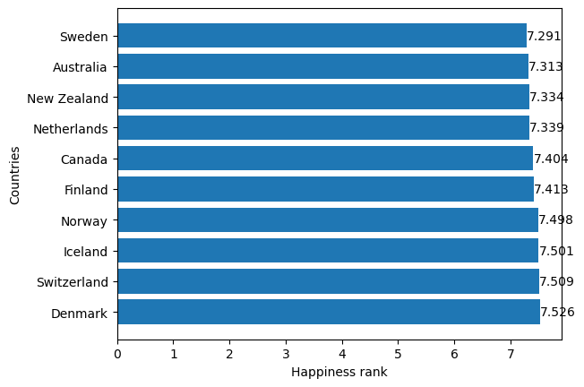

```python
top_10 = df_2016.sort_values(
    by='Happiness_Score',
    ascending=False
).head(10)

bar= plt.barh(top_10["Country"],top_10["Happiness_Score"])
plt.bar_label(bar)
plt.xlabel('Happiness rank')
plt.ylabel('Countries')
plt.show()
```

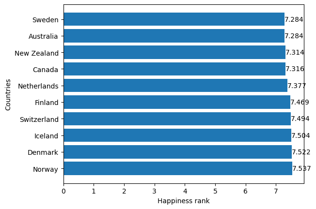

```python
top_10 = df_2017.sort_values(
    by='Happiness_Score',
    ascending=False
).head(10)

bar= plt.barh(top_10["Country"],top_10["Happiness_Score"])
plt.bar_label(bar)
plt.xlabel('Happiness rank')
plt.ylabel('Countries')
plt.show()
```

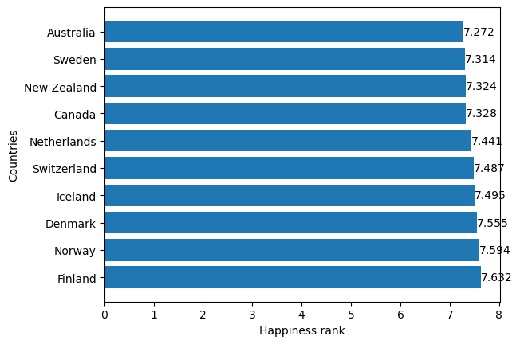

```python
top_10 = df_2018.sort_values(
    by='Happiness_Score',
    ascending=False
).head(10)

bar= plt.barh(top_10["Country"],top_10["Happiness_Score"])
plt.bar_label(bar)
plt.xlabel('Happiness rank')
plt.ylabel('Countries')
plt.show()
```

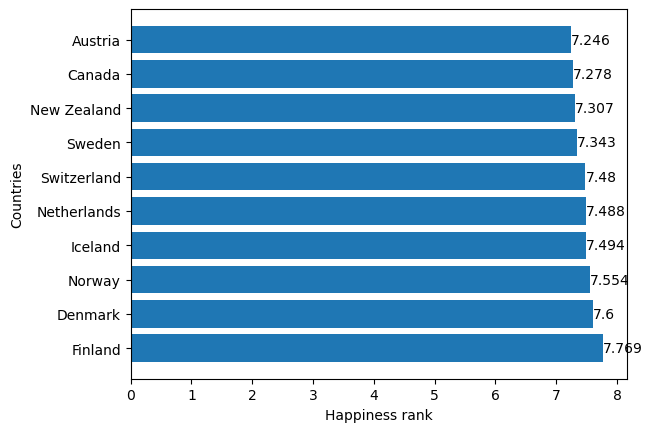

```python
top_10 = df_2019.sort_values(
    by='Happiness_Score',
    ascending=False
).head(10)

bar= plt.barh(top_10["Country"],top_10["Happiness_Score"])
plt.bar_label(bar)
plt.xlabel('Happiness rank')
plt.ylabel('Countries')
plt.show()
```

Nordic countries consistently rank high due to strong social support, high trust in government, and stable economic conditions.

Combining data of 5 years

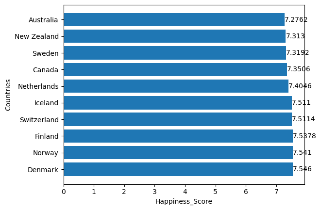

```python
All_df=pd.concat([df_2015,df_2016,df_2017,df_2018,df_2019],ignore_index=True)
Avg_happiness=(All_df.groupby('Country')['Happiness_Score'].mean().reset_index())
Top10=Avg_happiness.sort_values(by='Happiness_Score', ascending=False).head(10)
bar= plt.barh(Top10["Country"],Top10["Happiness_Score"])
plt.bar_label(bar)
plt.xlabel('Happiness_Score')
plt.ylabel('Countries')
plt.show()
```

Denmark,Norway,Finland,Switzerland,Iceland,Netherlands,Canada,Sweden,New Zealand & Australia are top 10 countries which have been consistently performing well on multiple metrics,cumulative score of which is 'Happiness Score'.

2. How does GDP per capita relate to happiness score?

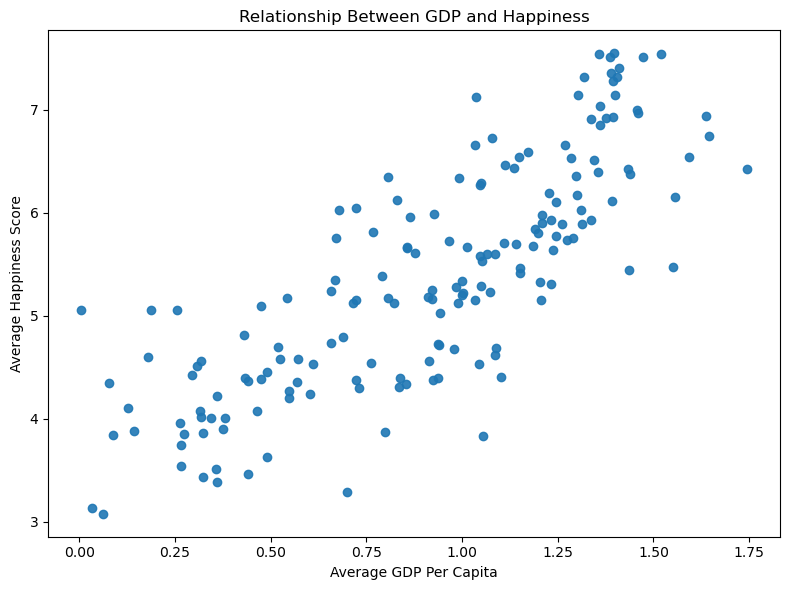

```python
Avg_gdp_happiness =(All_df.groupby('Country')[['GDP_Per_Capita', 'Happiness_Score']].mean().reset_index())
#print(Avg_gdp_happiness)
#Ploting Scatter Plot
plt.figure(figsize=(8,6))
plt.scatter(
    Avg_gdp_happiness['GDP_Per_Capita'],
    Avg_gdp_happiness['Happiness_Score'],
    alpha=0.9
)

plt.xlabel('Average GDP Per Capita')
plt.ylabel('Average Happiness Score')
plt.title('Relationship Between GDP and Happiness')
plt.tight_layout()
plt.show()
```

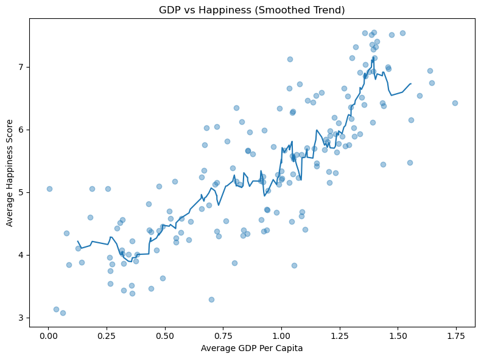

```python
sorted_df = Avg_gdp_happiness.sort_values('GDP_Per_Capita')

# Rolling mean (smooth trend)
sorted_df['Happiness_MA'] = (
    sorted_df['Happiness_Score']
    .rolling(window=10, center=True)
    .mean()
)

plt.figure(figsize=(8,6))

plt.scatter(
    sorted_df['GDP_Per_Capita'],
    sorted_df['Happiness_Score'],
    alpha=0.4
)

plt.plot(
    sorted_df['GDP_Per_Capita'],
    sorted_df['Happiness_MA']
)

plt.xlabel('Average GDP Per Capita')
plt.ylabel('Average Happiness Score')
plt.title('GDP vs Happiness (Smoothed Trend)')
plt.tight_layout()
plt.show()
```

The relation with GDP per capita income and happiness is almost linear. More the per capita income better the happiness score of a country

3. Is life expectancy strongly linked to happiness?

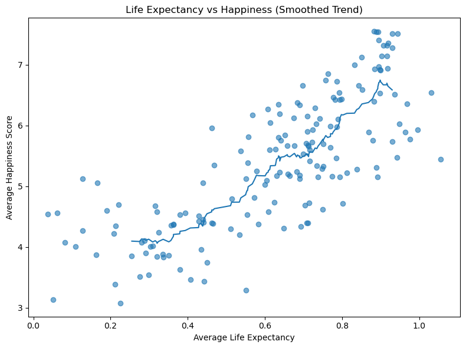

```python
Avg_Life_Expectancy=(All_df.groupby('Country')[['Healthy_Life_Expectancy','Happiness_Score']].mean().reset_index())
Sorted_df= Avg_Life_Expectancy.sort_values('Healthy_Life_Expectancy')
# Rolling Mean (smooth trend)

Sorted_df['Happiness_Score_MA']=(
    Sorted_df['Happiness_Score']
    .rolling(window=30,center=True)
    .mean())
plt.figure(figsize=(8,6))

plt.scatter(
    Sorted_df['Healthy_Life_Expectancy'],
    Sorted_df['Happiness_Score'],
    alpha=0.6
)

plt.plot(
   Sorted_df['Healthy_Life_Expectancy'],
   Sorted_df['Happiness_Score_MA']
)

plt.xlabel('Average Life Expectancy')
plt.ylabel('Average Happiness Score')
plt.title('Life Expectancy vs Happiness (Smoothed Trend)')
plt.tight_layout()
plt.show()
```

As above scatter plot dipicts the relation between happiness score and life expectancy is almost linear therefore life expectancy is strongly related to Happiness

4. Does social support matter more than economic strength?

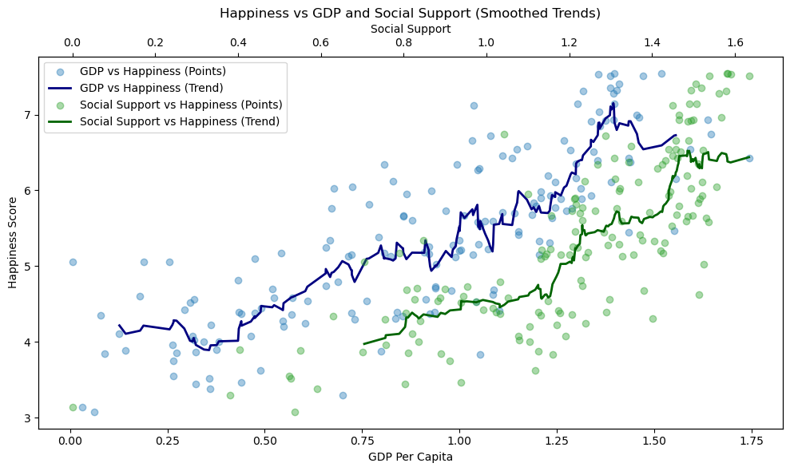

```python
plt.figure(figsize=(10,6))

# ---------- GDP vs Happiness ----------
sorted_gdp = Avg_gdp_happiness.sort_values('GDP_Per_Capita')
sorted_gdp['Happiness_MA_GDP'] = (
    sorted_gdp['Happiness_Score']
    .rolling(window=10, center=True)
    .mean()
)

ax1 = plt.gca()

# GDP scatter (blue)
ax1.scatter(
    sorted_gdp['GDP_Per_Capita'],
    sorted_gdp['Happiness_Score'],
    alpha=0.4,
    color='tab:blue',
    label='GDP vs Happiness (Points)'
)

# GDP trend line (dark blue)
ax1.plot(
    sorted_gdp['GDP_Per_Capita'],
    sorted_gdp['Happiness_MA_GDP'],
    color='navy',
    linewidth=2,
    label='GDP vs Happiness (Trend)'
)

ax1.set_xlabel('GDP Per Capita')
ax1.set_ylabel('Happiness Score')

# ---------- Social Support vs Happiness ----------
Avg_Social_Support = (
    All_df
    .groupby('Country')[['Social_support', 'Happiness_Score']]
    .mean()
    .reset_index()
)

sorted_social = Avg_Social_Support.sort_values('Social_support')
sorted_social['Happiness_MA_Social'] = (
    sorted_social['Happiness_Score']
    .rolling(window=20, center=True)
    .mean()
)

ax2 = ax1.twiny()

# Social support scatter (green)
ax2.scatter(
    sorted_social['Social_support'],
    sorted_social['Happiness_Score'],
    alpha=0.4,
    color='tab:green',
    label='Social Support vs Happiness (Points)'
)

# Social support trend line (dark green)
ax2.plot(
    sorted_social['Social_support'],
    sorted_social['Happiness_MA_Social'],
    color='darkgreen',
    linewidth=2,
    label='Social Support vs Happiness (Trend)'
)

ax2.set_xlabel('Social Support')

# ---------- Combined Legend ----------
lines1, labels1 = ax1.get_legend_handles_labels()
lines2, labels2 = ax2.get_legend_handles_labels()

plt.legend(
    lines1 + lines2,
    labels1 + labels2,
    loc='best'
)

plt.title('Happiness vs GDP and Social Support (Smoothed Trends)')
plt.tight_layout()
plt.show()
```

the behaviour of Happiness and Social support trends shows social support does not matter more than economic strengh. rather both are equally important

```python
All_df[['GDP_Per_Capita','Social_support','Happiness_Score']].corr()
```

|  | GDP_Per_Capita | Social_support | Happiness_Score |
| --- | --- | --- | --- |
| GDP_Per_Capita | 1.000000 | 0.713293 | 0.789513 |
| Social_support | 0.713293 | 1.000000 | 0.761081 |
| Happiness_Score | 0.789513 | 0.761081 | 1.000000 |

```python
Avg_happiness = (
    All_df
    .groupby('Country')['Happiness_Score']
    .mean()
    .reset_index()
)

# Create happiness clusters
Avg_happiness['Happiness_Level'] = pd.qcut(
    Avg_happiness['Happiness_Score'],
    q=3,
    labels=['Low', 'Medium', 'High']
)
Avg_happiness
```

|  | Country | Happiness_Score | Happiness_Level |
| --- | --- | --- | --- |
| 0 | Afghanistan | 3.51280 | Low |
| 1 | Albania | 4.71260 | Low |
| 2 | Algeria | 5.66760 | Medium |
| 3 | Angola | 3.87225 | Low |
| 4 | Argentina | 6.45940 | High |
| ... | ... | ... | ... |
| 165 | Venezuela | 5.53140 | Medium |
| 166 | Vietnam | 5.15460 | Medium |
| 167 | Yemen | 3.62580 | Low |
| 168 | Zambia | 4.58440 | Low |
| 169 | Zimbabwe | 4.00660 | Low |

170 rows × 3 columns

```python
High_happiness_countries = (
    Avg_happiness
    [Avg_happiness['Happiness_Level'] == 'High']
    .sort_values('Happiness_Score', ascending=False)
    .reset_index()
)

High_happiness_countries
```

|  | index | Country | Happiness_Score | Happiness_Level |
| --- | --- | --- | --- | --- |
| 0 | 38 | Denmark | 7.5460 | High |
| 1 | 111 | Norway | 7.5410 | High |
| 2 | 46 | Finland | 7.5378 | High |
| 3 | 145 | Switzerland | 7.5114 | High |
| 4 | 61 | Iceland | 7.5110 | High |
| 5 | 103 | Netherlands | 7.4046 | High |
| 6 | 25 | Canada | 7.3506 | High |
| 7 | 144 | Sweden | 7.3192 | High |
| 8 | 104 | New Zealand | 7.3130 | High |
| 9 | 6 | Australia | 7.2762 | High |
| 10 | 67 | Israel | 7.1422 | High |
| 11 | 7 | Austria | 7.1420 | High |
| 12 | 34 | Costa Rica | 7.1262 | High |
| 13 | 121 | Puerto Rico | 7.0390 | High |
| 14 | 162 | United States | 6.9988 | High |
| 15 | 66 | Ireland | 6.9644 | High |
| 16 | 85 | Luxembourg | 6.9360 | High |
| 17 | 51 | Germany | 6.9290 | High |
| 18 | 12 | Belgium | 6.9214 | High |
| 19 | 161 | United Kingdom | 6.9100 | High |
| 20 | 112 | Oman | 6.8530 | High |
| 21 | 160 | United Arab Emirates | 6.7442 | High |
| 22 | 94 | Mexico | 6.7252 | High |
| 23 | 19 | Brazil | 6.6578 | High |
| 24 | 37 | Czech Republic | 6.6546 | High |
| 25 | 28 | Chile | 6.5894 | High |
| 26 | 130 | Singapore | 6.5428 | High |
| 27 | 115 | Panama | 6.5380 | High |
| 28 | 91 | Malta | 6.5340 | High |
| 29 | 47 | France | 6.5152 | High |
| 30 | 4 | Argentina | 6.4594 | High |
| 31 | 163 | Uruguay | 6.4312 | High |
| 32 | 148 | Taiwan Province of China | 6.4220 | High |
| 33 | 122 | Qatar | 6.4218 | High |
| 34 | 147 | Taiwan | 6.3910 | High |
| 35 | 126 | Saudi Arabia | 6.3760 | High |
| 36 | 139 | Spain | 6.3514 | High |
| 37 | 54 | Guatemala | 6.3438 | High |
| 38 | 30 | Colombia | 6.3400 | High |
| 39 | 151 | Thailand | 6.2866 | High |
| 40 | 142 | Suriname | 6.2690 | High |
| 41 | 153 | Trinidad & Tobago | 6.1920 | High |
| 42 | 154 | Trinidad and Tobago | 6.1680 | High |
| 43 | 76 | Kuwait | 6.1486 | High |
| 44 | 43 | El Salvador | 6.1242 | High |
| 45 | 9 | Bahrain | 6.1138 | High |
| 46 | 131 | Slovakia | 6.1084 | High |
| 47 | 164 | Uzbekistan | 6.0462 | High |
| 48 | 105 | Nicaragua | 6.0274 | High |
| 49 | 68 | Italy | 6.0224 | High |
| 50 | 41 | Ecuador | 5.9920 | High |
| 51 | 119 | Poland | 5.9808 | High |
| 52 | 13 | Belize | 5.9560 | High |
| 53 | 84 | Lithuania | 5.9298 | High |
| 54 | 71 | Japan | 5.9258 | High |
| 55 | 89 | Malaysia | 5.9040 | High |
| 56 | 132 | Slovenia | 5.8880 | High |

```python
Medium_happiness_countries = (
    Avg_happiness
    [Avg_happiness['Happiness_Level'] == 'Medium']
    .sort_values('Happiness_Score', ascending=False)
    .reset_index()
)

Medium_happiness_countries
```

|  | index | Country | Happiness_Score | Happiness_Level |
| --- | --- | --- | --- | --- |
| 0 | 137 | South Korea | 5.885400 | Medium |
| 1 | 73 | Kazakhstan | 5.838400 | Medium |
| 2 | 16 | Bolivia | 5.813200 | Medium |
| 3 | 124 | Russia | 5.798600 | Medium |
| 4 | 110 | Northern Cyprus | 5.776500 | Medium |
| 5 | 108 | North Cyprus | 5.758667 | Medium |
| 6 | 95 | Moldova | 5.758600 | Medium |
| 7 | 36 | Cyprus | 5.732800 | Medium |
| 8 | 117 | Peru | 5.728400 | Medium |
| 9 | 93 | Mauritius | 5.706600 | Medium |
| 10 | 123 | Romania | 5.698400 | Medium |
| 11 | 79 | Latvia | 5.676200 | Medium |
| 12 | 2 | Algeria | 5.667600 | Medium |
| 13 | 116 | Paraguay | 5.666600 | Medium |
| 14 | 70 | Jamaica | 5.662000 | Medium |
| 15 | 44 | Estonia | 5.637800 | Medium |
| 16 | 75 | Kosovo | 5.606200 | Medium |
| 17 | 11 | Belarus | 5.598000 | Medium |
| 18 | 83 | Libya | 5.597000 | Medium |
| 19 | 157 | Turkmenistan | 5.582200 | Medium |
| 20 | 165 | Venezuela | 5.531400 | Medium |
| 21 | 59 | Hong Kong S.A.R., China | 5.472000 | Medium |
| 22 | 35 | Croatia | 5.458600 | Medium |
| 23 | 58 | Hong Kong | 5.448000 | Medium |
| 24 | 156 | Turkey | 5.415400 | Medium |
| 25 | 118 | Philippines | 5.387400 | Medium |
| 26 | 113 | Pakistan | 5.344000 | Medium |
| 27 | 128 | Serbia | 5.339200 | Medium |
| 28 | 60 | Hungary | 5.329400 | Medium |
| 29 | 120 | Portugal | 5.304600 | Medium |
| 30 | 97 | Montenegro | 5.292000 | Medium |
| 31 | 109 | North Macedonia | 5.274000 | Medium |
| 32 | 63 | Indonesia | 5.252000 | Medium |
| 33 | 57 | Honduras | 5.240800 | Medium |
| 34 | 8 | Azerbaijan | 5.229200 | Medium |
| 35 | 29 | China | 5.219000 | Medium |
| 36 | 40 | Dominican Republic | 5.199400 | Medium |
| 37 | 72 | Jordan | 5.179600 | Medium |
| 38 | 77 | Kyrgyzstan | 5.173400 | Medium |
| 39 | 98 | Morocco | 5.172200 | Medium |
| 40 | 17 | Bosnia and Herzegovina | 5.161800 | Medium |
| 41 | 166 | Vietnam | 5.154600 | Medium |
| 42 | 53 | Greece | 5.152400 | Medium |
| 43 | 80 | Lebanon | 5.149600 | Medium |
| 44 | 107 | Nigeria | 5.127400 | Medium |
| 45 | 15 | Bhutan | 5.124800 | Medium |
| 46 | 86 | Macedonia | 5.122000 | Medium |
| 47 | 149 | Tajikistan | 5.097800 | Medium |
| 48 | 133 | Somalia | 5.060250 | Medium |
| 49 | 134 | Somaliland Region | 5.057000 | Medium |
| 50 | 135 | Somaliland region | 5.057000 | Medium |
| 51 | 96 | Mongolia | 5.029200 | Medium |
| 52 | 102 | Nepal | 4.812400 | Medium |
| 53 | 78 | Laos | 4.792750 | Medium |
| 54 | 114 | Palestinian Territories | 4.736600 | Medium |
| 55 | 155 | Tunisia | 4.728400 | Medium |

```python
low_happiness_countries = (
    Avg_happiness
    [Avg_happiness['Happiness_Level'] == 'Low']
    .sort_values('Happiness_Score', ascending=False)
    .reset_index()
)

low_happiness_countries
```

|  | index | Country | Happiness_Score | Happiness_Level |
| --- | --- | --- | --- | --- |
| 0 | 1 | Albania | 4.712600 | Low |
| 1 | 24 | Cameroon | 4.695800 | Low |
| 2 | 64 | Iran | 4.689200 | Low |
| 3 | 136 | South Africa | 4.675200 | Low |
| 4 | 20 | Bulgaria | 4.618600 | Low |
| 5 | 99 | Mozambique | 4.601000 | Low |
| 6 | 168 | Zambia | 4.584400 | Low |
| 7 | 10 | Bangladesh | 4.580200 | Low |
| 8 | 129 | Sierra Leone | 4.559200 | Low |
| 9 | 101 | Namibia | 4.557000 | Low |
| 10 | 143 | Swaziland | 4.539500 | Low |
| 11 | 52 | Ghana | 4.536400 | Low |
| 12 | 65 | Iraq | 4.528400 | Low |
| 13 | 49 | Gambia | 4.516000 | Low |
| 14 | 74 | Kenya | 4.449400 | Low |
| 15 | 45 | Ethiopia | 4.423200 | Low |
| 16 | 48 | Gabon | 4.407800 | Low |
| 17 | 127 | Senegal | 4.394000 | Low |
| 18 | 5 | Armenia | 4.393200 | Low |
| 19 | 140 | Sri Lanka | 4.392600 | Low |
| 20 | 100 | Myanmar | 4.383000 | Low |
| 21 | 32 | Congo (Brazzaville) | 4.377400 | Low |
| 22 | 42 | Egypt | 4.375200 | Low |
| 23 | 39 | Djibouti | 4.369000 | Low |
| 24 | 92 | Mauritania | 4.355000 | Low |
| 25 | 33 | Congo (Kinshasa) | 4.346400 | Low |
| 26 | 50 | Georgia | 4.338800 | Low |
| 27 | 159 | Ukraine | 4.307200 | Low |
| 28 | 62 | India | 4.297800 | Low |
| 29 | 69 | Ivory Coast | 4.273200 | Low |
| 30 | 141 | Sudan | 4.241750 | Low |
| 31 | 90 | Mali | 4.219000 | Low |
| 32 | 23 | Cambodia | 4.205400 | Low |
| 33 | 106 | Niger | 4.104600 | Low |
| 34 | 81 | Lesotho | 4.079000 | Low |
| 35 | 21 | Burkina Faso | 4.073800 | Low |
| 36 | 158 | Uganda | 4.020200 | Low |
| 37 | 169 | Zimbabwe | 4.006600 | Low |
| 38 | 27 | Chad | 4.003400 | Low |
| 39 | 31 | Comoros | 3.961667 | Low |
| 40 | 14 | Benin | 3.901000 | Low |
| 41 | 88 | Malawi | 3.883000 | Low |
| 42 | 3 | Angola | 3.872250 | Low |
| 43 | 56 | Haiti | 3.865600 | Low |
| 44 | 55 | Guinea | 3.853600 | Low |
| 45 | 82 | Liberia | 3.839200 | Low |
| 46 | 18 | Botswana | 3.830000 | Low |
| 47 | 87 | Madagascar | 3.745400 | Low |
| 48 | 167 | Yemen | 3.625800 | Low |
| 49 | 152 | Togo | 3.544200 | Low |
| 50 | 0 | Afghanistan | 3.512800 | Low |
| 51 | 150 | Tanzania | 3.466000 | Low |
| 52 | 125 | Rwanda | 3.438600 | Low |
| 53 | 138 | South Sudan | 3.382500 | Low |
| 54 | 146 | Syria | 3.292200 | Low |
| 55 | 26 | Central African Republic | 3.134250 | Low |
| 56 | 22 | Burundi | 3.079000 | Low |

```python
All_df[['GDP_Per_Capita','Social_support','Happiness_Score']].corr()
```

|  | GDP_Per_Capita | Social_support | Happiness_Score |
| --- | --- | --- | --- |
| GDP_Per_Capita | 1.000000 | 0.713293 | 0.789513 |
| Social_support | 0.713293 | 1.000000 | 0.761081 |
| Happiness_Score | 0.789513 | 0.761081 | 1.000000 |

# Reccomendations

World Happiness Data Analysis clearly demonstrate following points:

Countries with good per capita income, healthy life expectancy and Social support have been consistently doing well in this list for 5 subsequent years. citizens of the country off worries about attaining basic living standards, healthcare are more likely to be genorous and help others wholeheartedly citizens who have been given old age allowances, unemployement allowances, disability support and other social support benefits to underpreviledged class more likely trust government and because of this social support schemes people are more free to make life choices. e.g Denmark with happiness Score=7.5460 has also performed in per capita income=1.383(aprx),healthy life expectancy=0.996(Aprx) and Social support=1.573(Aprx)

For countries to perform well in this index must work on uplifting GPD per capita income, Healthacare facilities and enhancing social support for weaker section of the society.

GDP per capita income, Healthacare facilities, Social support and trust on govenrment are 4 metrics largely responsible for position in the list all of these metrics are equally important. because there are some coutries who have performed exceedingly well in one of these fronts but failed to secure rank in high happiness level cluster. e.g. China, India depite being into club of 10 largest economies in the world couldnt secure high level happiness cluster.